# 生存分析教程与数学原理详解

Philo Wen

2025-09-08

# 1 生存分析教程与数学原理详解

## 1.1 生存分析简介

生存分析是一种统计方法，用于分析事件发生的时间分布，特别适用于研究从开始时间到感兴趣事件（如死亡、疾病复发、设备故障等）发生的时间间隔。

**应用场景：** - 医学研究：患者存活时间、疾病复发时间分析 - 可靠性工程：设备故障时间分析 - 社会学研究：失业持续时间、婚姻持续时间分析 - 市场营销：客户流失时间分析

**特点：** - 处理删失数据（censored data） - 关注事件发生的时间分布 - 可以同时考虑多个影响因素

## 1.2 生存分析的数学基础

### 1.2.1 基本概念定义

在生存分析中，需要理解以下几个核心概念：

1. **生存时间（Survival Time）**：从起始事件到感兴趣事件发生的时间间隔，通常用符号 $T$ 表示。
2. **生存函数（Survival Function）**：表示个体在时间 $t$ 仍然存活的概率，记作 $S(t)$。

   $$S(t) = P(T > t)$$
3. **风险函数（Hazard Function）**：表示在时间 $t$ 已经存活的个体在接下来的极短时间内发生事件的概率，记作 $h(t)$。

   $$f(t) = \frac{dF(t)}{dt}$$

   其中 $F(t) = P(T \leq t)$ 是累积分布函数。

### 1.2.2 概念间的数学关系

这些概念之间存在以下重要的数学关系：

$$S(t) = 1 - F(t)$$
$$h(t) = \frac{f(t)}{S(t)}$$
$$S(t) = \exp(-H(t))$$

### 1.2.3 常用分布模型

生存分析中常用的概率分布模型包括：

1. **指数分布（Exponential Distribution）**：假设风险恒定

   $$h(t) = \lambda$$
   $$S(t) = \exp(-\lambda t)$$

   其中 $\lambda$ 是常数风险率。
2. **Weibull分布（Weibull Distribution）**：允许风险随时间增加或减少

   $$h(t) = k \lambda (\lambda t)^{k-1}$$
   $$S(t) = \exp(-(\lambda t)^k)$$

   其中 $\lambda > 0$ 是尺度参数，$k > 0$ 是形状参数。当 $k = 1$ 时，Weibull分布退化为指数分布。
3. **对数正态分布（Log-Normal Distribution）**：假设生存时间的对数服从正态分布
4. **对数 logistic分布（Log-Logistic Distribution）**：风险函数先增加后减少

让通过R代码来直观地理解这些分布：

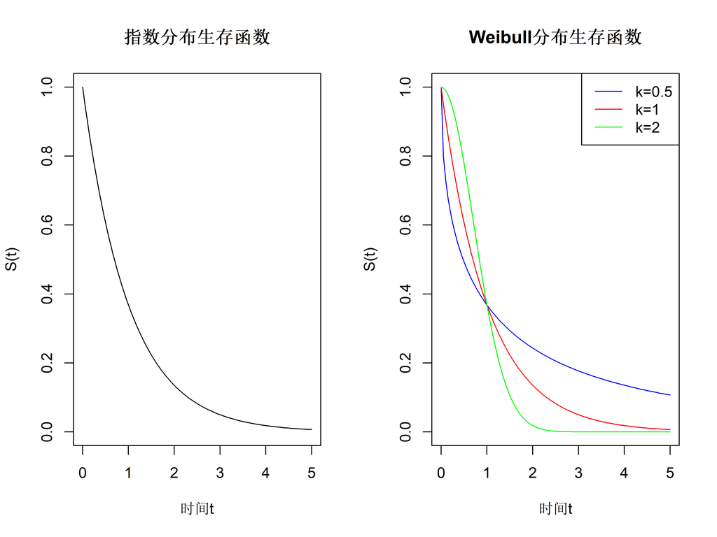

```r
# 定义分布函数
h_exp <- function(t, lambda) lambda
S_exp <- function(t, lambda) exp(-lambda * t)

h_weibull <- function(t, lambda, k) k * lambda * (lambda * t)^(k-1)
S_weibull <- function(t, lambda, k) exp(-(lambda * t)^k)

# 绘制生存函数曲线
t <- seq(0, 5, length = 100)
lambda <- 1

par(mfrow = c(1, 2))
plot(t, S_exp(t, lambda), type = "l", main = "指数分布生存函数",
     xlab = "时间t", ylab = "S(t)", ylim = c(0, 1))

plot(t, S_weibull(t, lambda, k=0.5), type = "l", col = "blue",
     main = "Weibull分布生存函数", xlab = "时间t", ylab = "S(t)", ylim = c(0, 1))
lines(t, S_weibull(t, lambda, k=1), col = "red")  # 等同于指数分布
lines(t, S_weibull(t, lambda, k=2), col = "green")
legend("topright", legend = c("k=0.5", "k=1", "k=2"),
       col = c("blue", "red", "green"), lty = 1)
```

```r
par(mfrow = c(1, 1))
```

## 1.3 包安装与加载

在R中进行生存分析，需要安装并加载以下关键包：

- `survival`：核心生存分析包，提供基础函数
- `survminer`：生存分析可视化工具
- `ggplot2`：数据可视化基础包
- `dplyr`：数据处理工具
- `tidyr`：数据整理工具

```r
# 安装必要的R包
if (!require(survival)) install.packages("survival")
if (!require(survminer)) install.packages("survminer")
if (!require(ggplot2)) install.packages("ggplot2")
if (!require(dplyr)) install.packages("dplyr")
if (!require(tidyr)) install.packages("tidyr")

# 加载R包
suppressPackageStartupMessages(library(survival))
suppressPackageStartupMessages(library(survminer))
suppressPackageStartupMessages(library(ggplot2))
suppressPackageStartupMessages(library(dplyr))
suppressPackageStartupMessages(library(tidyr))
```

## 1.4 数据准备

R语言提供了多个内置的生存分析数据集，将使用以下数据集进行演示：

1. **lung**：肺癌患者生存数据
2. **ovarian**：卵巢癌患者生存数据
3. **aml**：急性髓细胞白血病患者生存数据

让先查看这些数据集的基本结构：

```r
# 查看lung数据集结构
cat("=== lung数据集结构 ===\n")
```

```
## === lung数据集结构 ===
```

```r
str(lung)
```

```
## 'data.frame':    228 obs. of  10 variables:
##  $ inst     : num  3 3 3 5 1 12 7 11 1 7 ...
##  $ time     : num  306 455 1010 210 883 ...
##  $ status   : num  2 2 1 2 2 1 2 2 2 2 ...
##  $ age      : num  74 68 56 57 60 74 68 71 53 61 ...
##  $ sex      : num  1 1 1 1 1 1 2 2 1 1 ...
##  $ ph.ecog  : num  1 0 0 1 0 1 2 2 1 2 ...
##  $ ph.karno : num  90 90 90 90 100 50 70 60 70 70 ...
##  $ pat.karno: num  100 90 90 60 90 80 60 80 80 70 ...
##  $ meal.cal : num  1175 1225 NA 1150 NA ...
##  $ wt.loss  : num  NA 15 15 11 0 0 10 1 16 34 ...
```

```r
head(lung)
```

```
##   inst time status age sex ph.ecog ph.karno pat.karno meal.cal wt.loss
## 1    3  306      2  74   1       1       90       100     1175      NA
## 2    3  455      2  68   1       0       90        90     1225      15
## 3    3 1010      1  56   1       0       90        90       NA      15
## 4    5  210      2  57   1       1       90        60     1150      11
## 5    1  883      2  60   1       0      100        90       NA       0
## 6   12 1022      1  74   1       1       50        80      513       0
```

```r
# 查看ovarian数据集结构
cat("\n=== ovarian数据集结构 ===\n")
```

```
##
## === ovarian数据集结构 ===
```

```r
str(ovarian)
```

```
## 'data.frame':    26 obs. of  6 variables:
##  $ futime  : num  59 115 156 421 431 448 464 475 477 563 ...
##  $ fustat  : num  1 1 1 0 1 0 1 1 0 1 ...
##  $ age     : num  72.3 74.5 66.5 53.4 50.3 ...
##  $ resid.ds: num  2 2 2 2 2 1 2 2 2 1 ...
##  $ rx      : num  1 1 1 2 1 1 2 2 1 2 ...
##  $ ecog.ps : num  1 1 2 1 1 2 2 2 1 2 ...
```

```r
head(ovarian)
```

```
##   futime fustat     age resid.ds rx ecog.ps
## 1     59      1 72.3315        2  1       1
## 2    115      1 74.4932        2  1       1
## 3    156      1 66.4658        2  1       2
## 4    421      0 53.3644        2  2       1
## 5    431      1 50.3397        2  1       1
## 6    448      0 56.4301        1  1       2
```

```r
# 查看aml数据集结构
cat("\n=== aml数据集结构 ===\n")
```

```
##
## === aml数据集结构 ===
```

```r
str(aml)
```

```
## 'data.frame':    23 obs. of  3 variables:
##  $ time  : num  9 13 13 18 23 28 31 34 45 48 ...
##  $ status: num  1 1 0 1 1 0 1 1 0 1 ...
##  $ x     : Factor w/ 2 levels "Maintained","Nonmaintained": 1 1 1 1 1 1 1 1 1 1 ...
```

```r
head(aml)
```

```
##   time status          x
## 1    9      1 Maintained
## 2   13      1 Maintained
## 3   13      0 Maintained
## 4   18      1 Maintained
## 5   23      1 Maintained
## 6   28      0 Maintained
```

```r
# 数据预处理：将性别变量转换为因子
lung$sex <- factor(lung$sex, levels = c(1, 2), labels = c("男性", "女性"))
head(lung$sex)
```

```
## [1] 男性 男性 男性 男性 男性 男性
## Levels: 男性 女性
```

## 1.5 Kaplan-Meier生存曲线分析

Kaplan-Meier方法是生存分析中最常用的非参数方法，用于估计生存函数。该方法特别适用于处理含有删失数据的生存资料。

### 1.5.1 Kaplan-Meier估计的数学原理

Kaplan-Meier估计的基本思想是利用条件概率的乘法规则来估计生存函数。对于一组按时间排序的事件时间点 $t_1 < t_2 < ... < t_k$，其中 $d_i$ 是在时间 $t_i$ 发生的事件数，$n_i$ 是在时间 $t_i$ 开始时的风险人数（即在 $t_i$ 时刻仍然存活的个体数），则生存函数的Kaplan-Meier估计为：

$$\hat{S}(t) = \prod_{t_i \leq t} \left(1 - \frac{d_i}{n_i}\right)$$

### 1.5.2 创建生存对象

在R中，首先需要创建一个生存对象（Survival Object），这是进行生存分析的基础：

```r
# 创建生存对象
surv_object <- Surv(time = lung$time, event = lung$status)
cat("生存对象的前6行：\n")
```

```
## 生存对象的前6行：
```

```r
head(surv_object)
```

```
## [1]  306   455  1010+  210   883  1022+
```

生存对象的每一个值，都对应**1名患者的“生存状态+时间”**，格式只有两种：`数字` 或 `数字+`，这是生存数据的核心特点（区别于普通数据）。

| 格式 | 含义 | 对应 `lung` 数据的实际意义（以肺癌为例） |
| --- | --- | --- |
| 纯数字（如306） | **事件发生数据**：患者在随访 `数字` 天后，发生了研究关注的“事件”（这里是死亡）。 | 第1名患者：随访306天后死亡。 |
| 数字+（如1010+） | **截尾数据（Censored Data）**：患者在随访 `数字` 天后，**未发生事件**，数据被截断。 | 第3名患者：随访1010天后仍存活，或失访、研究结束，未观察到死亡。 |

- 第1个值 `306`：第1名肺癌患者，随访306天后死亡（事件发生）。
- 第2个值 `455`：第2名患者，随访455天后死亡（事件发生）。
- 第3个值 `1010+`：第3名患者，随访1010天后**未死亡**（可能是研究结束时仍存活，或中途失访），数据截尾。
- 第10个值 `166`：第10名患者，随访166天后死亡。
- 第19个值 `61`：第19名患者，随访61天后死亡（短期事件）。
- 第24个值 `965+`：第24名患者，随访965天后仍存活，数据截尾。

生存数据的特殊性（含截尾）决定了它不能用普通回归（如线性回归）分析，必须用专门的生存分析方法。而“生存对象”的作用就是：  
**将“生存时间”和“事件状态”整合为一个统一的载体，告诉后续分析函数（如 `kmfit <- survfit(Surv(...) ~ 1)`）：哪些是事件数据、哪些是截尾数据，从而正确计算生存概率（如Kaplan-Meier估计）。**

### 1.5.3 基础KM分析

接下来，使用`survfit()`函数进行Kaplan-Meier估计：

```r
# 进行KM估计
km_fit <- survfit(surv_object ~ 1, data = lung)
cat("KM估计结果摘要：\n")
```

```
## KM估计结果摘要：
```

```r
summary(km_fit)
```

```
## Call: survfit(formula = surv_object ~ 1, data = lung)
##
##  time n.risk n.event survival std.err lower 95% CI upper 95% CI
##     5    228       1   0.9956 0.00438       0.9871        1.000
##    11    227       3   0.9825 0.00869       0.9656        1.000
##    12    224       1   0.9781 0.00970       0.9592        0.997
##    13    223       2   0.9693 0.01142       0.9472        0.992
##    15    221       1   0.9649 0.01219       0.9413        0.989
##    26    220       1   0.9605 0.01290       0.9356        0.986
##    30    219       1   0.9561 0.01356       0.9299        0.983
##    31    218       1   0.9518 0.01419       0.9243        0.980
##    53    217       2   0.9430 0.01536       0.9134        0.974
##    54    215       1   0.9386 0.01590       0.9079        0.970
##    59    214       1   0.9342 0.01642       0.9026        0.967
##    60    213       2   0.9254 0.01740       0.8920        0.960
```

[output cut: 127 more lines]

`survfit()`函数的第一个参数是一个公式，`~ 1`表示不考虑分组因素，即对整个样本进行估计。

### 1.5.4 分组KM分析

可以按不同的因素（如性别）对样本进行分组，比较不同组之间的生存差异：

```r
# 分组KM分析（按性别）
km_fit_sex <- survfit(surv_object ~ sex, data = lung)
cat("按性别分组的KM估计结果摘要：\n")
```

```
## 按性别分组的KM估计结果摘要：
```

```r
summary(km_fit_sex)
```

```
## Call: survfit(formula = surv_object ~ sex, data = lung)
##
##                 sex=男性
##  time n.risk n.event survival std.err lower 95% CI upper 95% CI
##    11    138       3   0.9783  0.0124       0.9542        1.000
##    12    135       1   0.9710  0.0143       0.9434        0.999
##    13    134       2   0.9565  0.0174       0.9231        0.991
##    15    132       1   0.9493  0.0187       0.9134        0.987
##    26    131       1   0.9420  0.0199       0.9038        0.982
##    30    130       1   0.9348  0.0210       0.8945        0.977
##    31    129       1   0.9275  0.0221       0.8853        0.972
##    53    128       2   0.9130  0.0240       0.8672        0.961
##    54    126       1   0.9058  0.0249       0.8583        0.956
##    59    125       1   0.8986  0.0257       0.8496        0.950
##    60    124       1   0.8913  0.0265       0.8409        0.945
```

[output cut: 142 more lines]

### 1.5.5 绘制KM生存曲线

使用`survminer`包中的`ggsurvplot()`函数可以绘制精美的生存曲线：

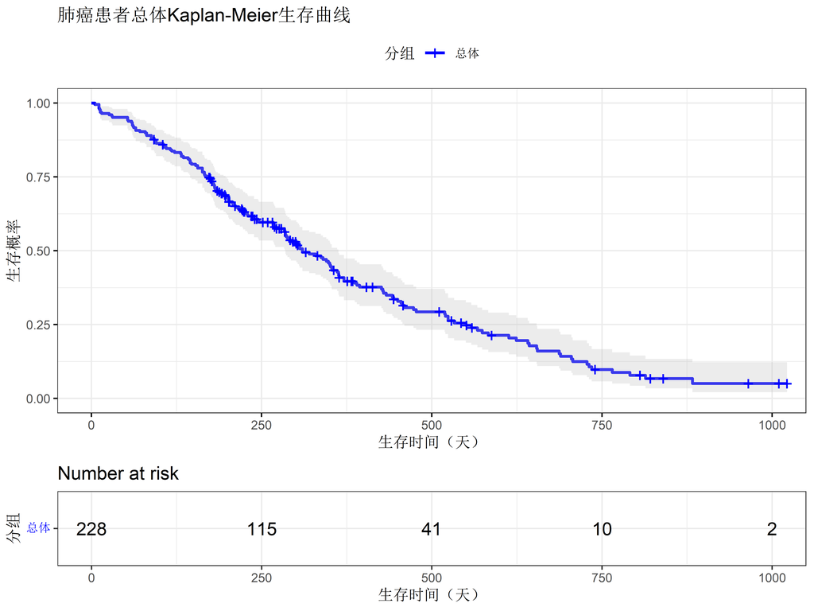

```r
# 绘制基础KM曲线
p1 <- ggsurvplot(
  km_fit,
  data = lung,
  risk.table = TRUE,         # 添加风险人数表
  pval = FALSE,              # 单组数据不需要p值检验
  conf.int = TRUE,           # 添加置信区间
  xlab = "生存时间（天）",    # x轴标签
  ylab = "生存概率",          # y轴标签
  title = "肺癌患者总体Kaplan-Meier生存曲线", # 标题
  legend.title = "分组",      # 图例标题
  legend.labs = c("总体"),    # 图例标签
  palette = "blue",          # 颜色
  ggtheme = theme_bw()        # 使用黑白主题
)
p1
```

**图1：肺癌患者总体Kaplan-Meier生存曲线** 该图展示了肺癌患者的整体生存情况。生存曲线随着时间的推移逐渐下降，表示患者存活到特定时间点的概率逐渐降低。风险表显示了不同时间点的风险人数。

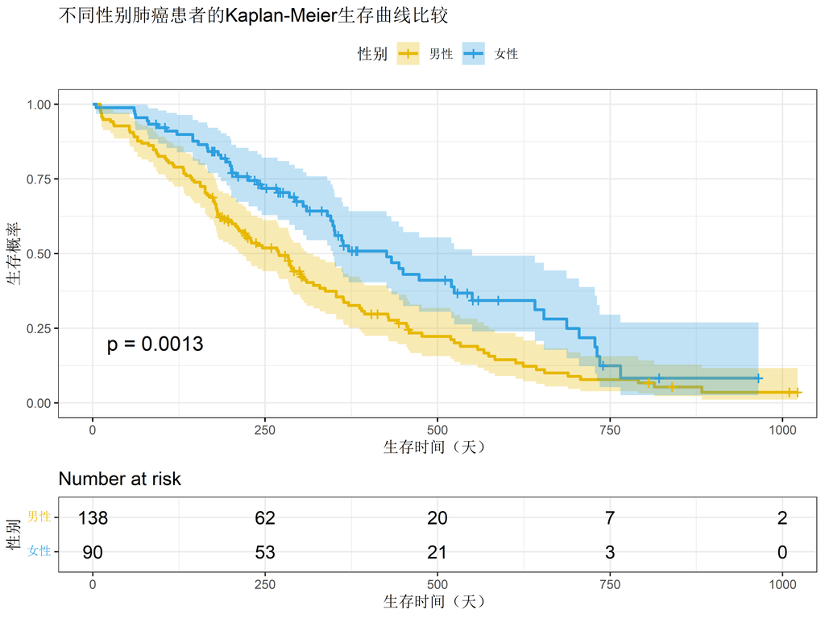

```r
# 绘制分组KM曲线
p2 <- ggsurvplot(
  km_fit_sex,
  data = lung,
  risk.table = TRUE,         # 添加风险人数表
  pval = TRUE,               # 添加Log-rank检验p值
  conf.int = TRUE,           # 添加置信区间
  xlab = "生存时间（天）",    # x轴标签
  ylab = "生存概率",          # y轴标签
  title = "不同性别肺癌患者的Kaplan-Meier生存曲线比较", # 标题
  legend.title = "性别",      # 图例标题
  legend.labs = c("男性", "女性"), # 图例标签
  palette = c("#E7B800", "#2E9FDF"), # 颜色
  ggtheme = theme_bw()        # 使用黑白主题
)
p2
```

**图2：按性别分组的肺癌患者生存曲线** 该图展示了肺癌患者中男性和女性的生存曲线比较。从图中可以看出，女性患者的生存曲线整体高于男性患者，提示性别可能是影响肺癌患者预后的一个因素。图下方的风险表显示了不同时间点各组的风险人数。 ### Log-rank检验

Log-rank检验是比较两组或多组生存曲线差异的非参数检验方法。在上面的分组KM曲线中，通过`pval = TRUE`参数已经添加了Log-rank检验的结果。

Log-rank检验的原假设是两组的生存函数相同，备择假设是至少有一组的生存函数不同。

也可以单独进行Log-rank检验：

```r
# 单独进行Log-rank检验
surv_diff <- survdiff(surv_object ~ sex, data = lung)
surv_diff
```

```
## Call:
## survdiff(formula = surv_object ~ sex, data = lung)
##
##            N Observed Expected (O-E)^2/E (O-E)^2/V
## sex=男性 138      112     91.6      4.55      10.3
## sex=女性  90       53     73.4      5.68      10.3
##
##  Chisq= 10.3  on 1 degrees of freedom, p= 0.001
```

## 1.6 Cox比例风险模型分析

Cox比例风险模型是生存分析中最常用的半参数回归模型，它允许同时考虑多个协变量对生存时间的影响。

### 1.6.1 Cox模型的数学原理

**1. Cox比例风险模型的基本形式** Cox比例风险模型的基本形式表示为：

$$h(t, \mathbf{x}) = h_0(t)
\exp(\mathbf{\beta}^T \mathbf{x})$$

其中各参数的含义如下： - $h(t, \mathbf{x})$：具有协变量 $\mathbf{x}$ 的个体在时间 $t$ 时的风险函数，描述该个体在时刻 $t$ 发生研究结局的瞬时风险； - $h_0(t)$：基准风险函数，指所有协变量取值均为0时，个体在时间 $t$ 的风险函数，仅与时间相关，与协变量无关； - $\mathbf{\beta}$：回归系数向量，每个元素对应一个协变量的回归系数，用于衡量该协变量对风险函数的影响方向和强度； - $\exp(\mathbf{\beta}^T \mathbf{x})$：风险比（Hazard Ratio, HR），若协变量为分类变量，可直接反映不同类别间的风险倍数关系；若为连续变量，可反映该变量每变化1个单位时风险的变化倍数。

**2. 比例风险假设（Proportional Hazards Assumption）** 比例风险假设是Cox模型的核心前提假设，其核心含义为：**不同协变量组合的个体，其风险函数之比不随时间 $t$ 变化，始终保持恒定**。

该假设的数学推导过程如下：

$$\frac{h(t, \mathbf{x}_1)}{h(t,
\mathbf{x}_2)} = \frac{h_0(t) \exp(\mathbf{\beta}^T
\mathbf{x}_1)}{h_0(t) \exp(\mathbf{\beta}^T \mathbf{x}_2)} =
\exp(\mathbf{\beta}^T (\mathbf{x}_1 - \mathbf{x}_2))$$

推导逻辑说明： 1. 分子分母中的基准风险函数 $h_0(t)$ 可相互抵消（因 $h_0(t)$ 与协变量无关）； 2. 根据指数运算性质 $\frac{\exp(a)}{\exp(b)} = \exp(a - b)$，将指数项合并； 3. 最终结果 $\exp(\mathbf{\beta}^T (\mathbf{x}_1 - \mathbf{x}_2))$ 仅与协变量差异（$\mathbf{x}_1 - \mathbf{x}_2$）和回归系数向量（$\mathbf{\beta}$）相关，与时间 $t$ 无关，验证了“风险比恒定”的假设。

### 1.6.2 基础Cox回归

在R中，使用`coxph()`函数拟合Cox比例风险模型：

```r
# 创建基础Cox模型（仅包含性别变量）
cox1 <- coxph(Surv(time, status) ~ sex, data = lung)
cat("基础Cox回归模型摘要：\n")
```

```
## 基础Cox回归模型摘要：
```

```r
summary(cox1)
```

```
## Call:
## coxph(formula = Surv(time, status) ~ sex, data = lung)
##
##   n= 228, number of events= 165
##
##            coef exp(coef) se(coef)      z Pr(>|z|)
## sex女性 -0.5310    0.5880   0.1672 -3.176  0.00149 **
## ---
## Signif. codes:  0 '***' 0.001 '**' 0.01 '*' 0.05 '.' 0.1 ' ' 1
##
##         exp(coef) exp(-coef) lower .95 upper .95
## sex女性     0.588      1.701    0.4237     0.816
##
## Concordance= 0.579  (se = 0.021 )
## Likelihood ratio test= 10.63  on 1 df,   p=0.001
## Wald test            = 10.09  on 1 df,   p=0.001
## Score (logrank) test = 10.33  on 1 df,   p=0.001
```

在Cox回归结果中，主要关注： - **回归系数（coef）**：表示协变量对风险的影响方向和大小 - **风险比（exp(coef)）**：表示协变量每增加一个单位，风险增加的倍数 - **p值**：表示协变量的统计显著性

### 1.6.3 多变量Cox回归

可以在模型中包含多个协变量，进行多变量生存分析：

```r
# 创建包含多个协变量的Cox模型
cox2 <- coxph(Surv(time, status) ~ sex + age + ph.ecog + wt.loss, data = lung)
cat("多变量Cox回归模型摘要：\n")
```

```
## 多变量Cox回归模型摘要：
```

```r
summary(cox2)
```

```
## Call:
## coxph(formula = Surv(time, status) ~ sex + age + ph.ecog + wt.loss,
##     data = lung)
##
##   n= 213, number of events= 151
##    (15 observations deleted due to missingness)
##
##              coef exp(coef)  se(coef)      z Pr(>|z|)
## sex女性 -0.590775  0.553898  0.175339 -3.369 0.000754 ***
## age      0.013369  1.013459  0.009628  1.389 0.164951
## ph.ecog  0.515111  1.673824  0.125988  4.089 4.34e-05 ***
## wt.loss -0.009006  0.991034  0.006658 -1.353 0.176135
## ---
## Signif. codes:  0 '***' 0.001 '**' 0.01 '*' 0.05 '.' 0.1 ' ' 1
##
##         exp(coef) exp(-coef) lower .95 upper .95
## sex女性    0.5539     1.8054    0.3928    0.7811
## age        1.0135     0.9867    0.9945    1.0328
## ph.ecog    1.6738     0.5974    1.3076    2.1427
## wt.loss    0.9910     1.0090    0.9782    1.0041
##
## Concordance= 0.647  (se = 0.026 )
## Likelihood ratio test= 31.02  on 4 df,   p=3e-06
## Wald test            = 29.94  on 4 df,   p=5e-06
## Score (logrank) test = 30.65  on 4 df,   p=4e-06
```

### 1.6.4 比例风险假设检验

使用Cox模型前，需要检验比例风险假设是否满足。常用的方法是Schoenfeld残差检验：

```r
# 使用Schoenfeld残差检验比例风险假设
test_ph <- cox.zph(cox2)
cat("比例风险假设检验结果：\n")
```

```
## 比例风险假设检验结果：
```

```r
test_ph
```

```
##          chisq df    p
## sex     2.6731  1 0.10
## age     0.4353  1 0.51
## ph.ecog 1.6355  1 0.20
## wt.loss 0.0457  1 0.83
## GLOBAL  4.7516  4 0.31
```

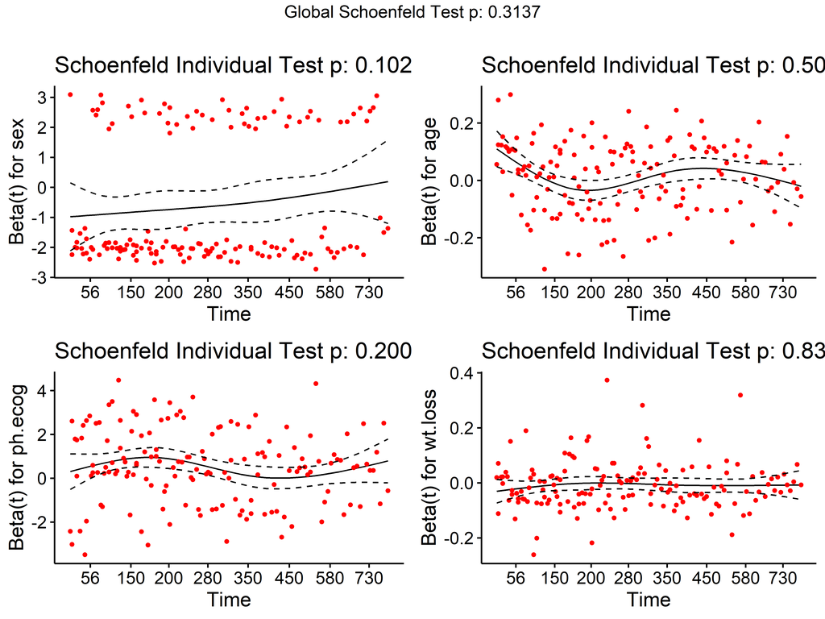

```r
# 可视化比例风险假设检验结果
p5 <- ggcoxzph(test_ph, se = TRUE)
p5
```

**图6：比例风险假设检验结果** 该图展示了Cox比例风险模型的比例风险假设检验结果。图中的曲线应该大致呈水平状态，没有明显的趋势，才能支持比例风险假设。从图中可以看出，的模型基本满足比例风险假设。 如果p值大于0.05，通常认为比例风险假设成立。

### 1.6.5 森林图展示Cox回归结果

森林图是展示Cox回归结果的常用可视化方法，可以直观地展示各个协变量的风险比及其置信区间：

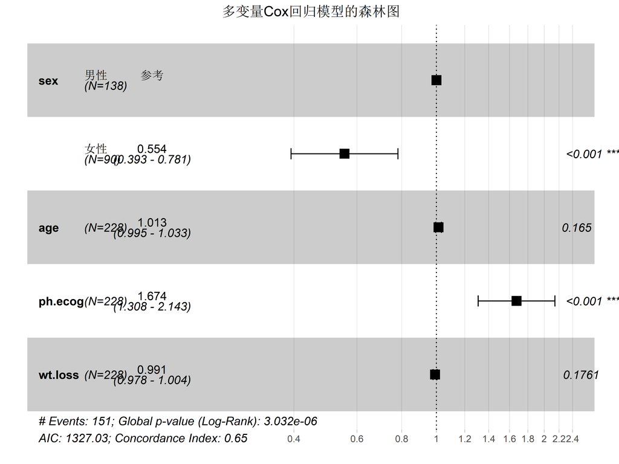

```r
# 森林图展示Cox回归结果
p6 <- ggforest(
  cox2,
  data = lung,
  main = "多变量Cox回归模型的森林图",
  cpositions = c(0.02, 0.1, 0.22),
  fontsize = 1.0,
  refLabel = "参考",
  noDigits = 3
)
p6
```

**图5：Cox比例风险模型的森林图** 该森林图展示了多变量Cox回归模型中各个协变量的风险比（HR）及其95%置信区间。森林图是展示Cox回归结果的常用方式，能够直观地显示每个协变量对生存时间的影响方向和强度。 ## 高级生存分析技术

### 1.6.6 时间依变协变量

在某些情况下，协变量的值可能随时间变化，这时需要使用时间依变协变量模型：

```r
# 创建时间依变协变量的Cox模型
# 这里使用模拟数据演示概念
set.seed(123)
n <- 100
time <- runif(n, 1, 100)
event <- rbinom(n, 1, 0.5)
covariate1 <- rnorm(n)
covariate2 <- rnorm(n)

# 创建时间依变协变量数据
data_temp <- data.frame(
  id = 1:n,
  time = time,
  event = event,
  covariate1 = covariate1,
  covariate2 = covariate2
)

# 演示时间依变协变量的模型设置
cat("时间依变协变量的模型设置示例：\n")
```

```
## 时间依变协变量的模型设置示例：
```

```r
cat("model <- coxph(Surv(start, stop, event) ~ covariate1 + covariate2, data = time_dependent_data)")
```

```
## model <- coxph(Surv(start, stop, event) ~ covariate1 + covariate2, data = time_dependent_data)
```

### 1.6.7 竞争风险模型

在实际研究中，可能存在多种可能导致观察结束的事件（如患者可能死于其他疾病而不是研究关注的疾病），这时需要使用竞争风险模型：

```r
# 演示竞争风险模型的概念
cat("竞争风险模型的模型设置示例：\n")
```

```
## 竞争风险模型的模型设置示例：
```

```r
cat("cmprsk_model <- coxph(Surv(time, status) ~ covariate1 + covariate2, data = data, cluster = id)")
```

```
## cmprsk_model <- coxph(Surv(time, status) ~ covariate1 + covariate2, data = data, cluster = id)
```

## 1.7 生存分析结果的可视化展示

### 1.7.1 组合多个生存曲线图

可以组合多个生存曲线图，方便比较不同数据集或不同分组的结果：

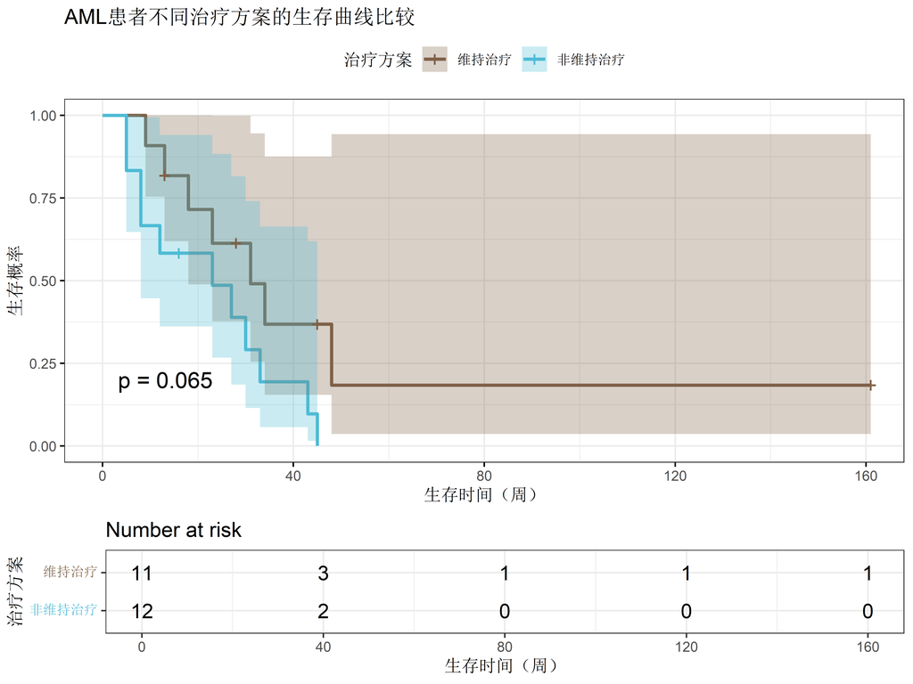

```r
# 准备AML数据集
aml$group <- factor(aml$x, levels = c("Maintained", "Nonmaintained"),
                    labels = c("维持治疗", "非维持治疗"))
surv_object_aml <- Surv(time = aml$time, event = aml$status)
km_fit_aml <- survfit(surv_object_aml ~ group, data = aml)

# 绘制AML患者的KM曲线
p4 <- ggsurvplot(
  km_fit_aml,
  data = aml,
  risk.table = TRUE,
  pval = TRUE,
  conf.int = TRUE,
  xlab = "生存时间（周）",
  ylab = "生存概率",
  title = "AML患者不同治疗方案的生存曲线比较",
  legend.title = "治疗方案",
  legend.labs = c("维持治疗", "非维持治疗"),
  palette = c("#7E6148FF", "#4DBBD5FF"),
  ggtheme = theme_bw()
)

p4
```

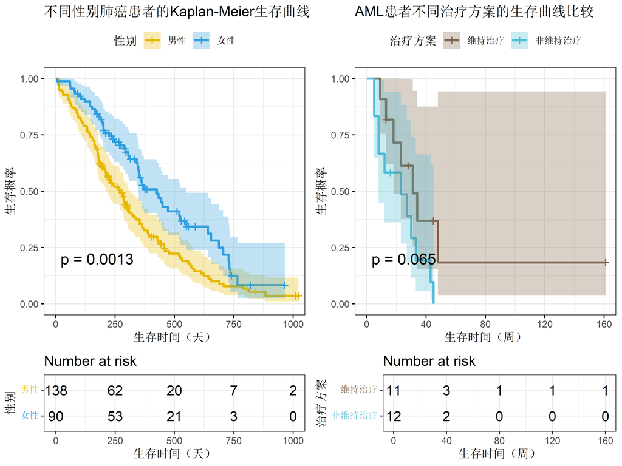

```r
# 组合生存曲线图
p_list <- list(p2, p4)
combined_plots <- arrange_ggsurvplots(p_list, ncol = 2, nrow = 1)
```

```r
combined_plots
```

**图7：组合生存曲线图** 该图组合了肺癌患者按性别分组的生存曲线和AML患者按治疗方案分组的生存曲线，方便直观比较不同数据集的生存分析结果。组合图对于展示多个相关分析结果非常有用。 ### 风险函数可视化

可以使用`ggcoxfunctional()`函数可视化协变量与风险之间的函数关系：

```r
# 加载必要的库
library(survival)
library(survminer)

# 查看数据集中的缺失值情况
sum(is.na(lung))
```

```
## [1] 67
```

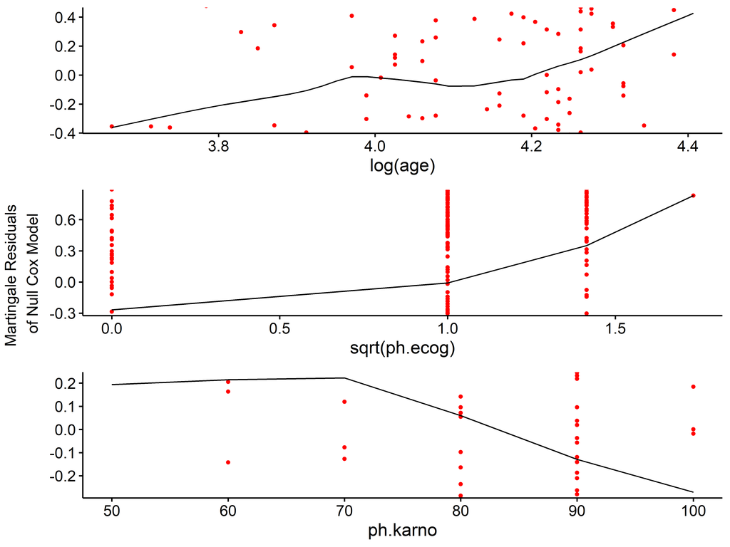

```r
# 处理缺失值 - 这里选择删除包含缺失值的行
lung_clean <- na.omit(lung[, c("time", "status", "age", "ph.ecog", "ph.karno")])


# 重新绘制风险函数图
p8 <- ggcoxfunctional(
  Surv(time, status) ~ log(age) + sqrt(ph.ecog) + ph.karno,
  data = lung_clean
)

# 显示图形
print(p8)
```

**图8：协变量与风险之间的函数关系图** 该图展示了各个协变量与风险之间的函数关系，用于评估协变量是否需要进行函数转换。图中曲线应该大致呈线性，才能支持协变量与风险之间的线性关系假设。

## 1.8 总结与讨论

本教程详细介绍了生存分析的数学原理和R语言实现，包括：

1. **生存分析的数学基础**：生存函数、风险函数、累积风险函数等核心概念及其数学关系
2. **常用分布模型**：指数分布、Weibull分布等
3. **Kaplan-Meier方法**：非参数生存函数估计及其可视化
4. **Cox比例风险模型**：半参数回归模型，用于分析多个协变量对生存时间的影响
5. **高级生存分析技术**：时间依变协变量、竞争风险模型等

## 1.9 附录：代码清单

这里提供了本教程中使用的所有主要函数，方便查阅和复习：

| 函数名 | 包 | 功能描述 |
| --- | --- | --- |
| Surv() | survival | 创建生存对象 |
| survfit() | survival | 进行Kaplan-Meier估计 |
| survdiff() | survival | 进行Log-rank检验 |
| coxph() | survival | 拟合Cox比例风险模型 |
| cox.zph() | survival | 检验比例风险假设 |
| ggsurvplot() | survminer | 绘制生存曲线 |
| ggforest() | survminer | 绘制Cox回归森林图 |
| ggcoxzph() | survminer | 可视化比例风险假设检验结果 |
| ggcoxfunctional() | survminer | 可视化协变量函数形式 |
| arrange_ggsurvplots() | survminer | 组合多个生存曲线图 |